# Final Project Using Mimic iii Data

```r
#long_title<- what effect is death rate
#count of long title
data4 %>% dplyr::count (long_title, sort= TRUE) # count of long_title
```

```
# A tibble: 4 x 2
  long_title                     n
  <fct>                      <int>
1 Acute Respiratory Failure   4848
2 OTHER                       3122
3 Chronic Airway Obstruction  2928
4 Pneumonia                   2706
```

```r
#dead by long_title
#1 Acute Respiratory Failure   4848
#2 OTHER                       3122
#3 Chronic Airway Obstruction  2928
#4 Pneumonia                   2706


data4 %>% dplyr::count (long_title, mortality, sort= TRUE) # count of
```

```
# A tibble: 8 x 3
  long_title                 mortality     n
  <fct>                      <fct>     <int>
1 Acute Respiratory Failure  FALSE      3549
2 Chronic Airway Obstruction FALSE      2710
3 OTHER                      FALSE      2364
4 Pneumonia                  FALSE      2364
5 Acute Respiratory Failure  TRUE       1299
6 OTHER                      TRUE        758
7 Pneumonia                  TRUE        342
8 Chronic Airway Obstruction TRUE        218
```

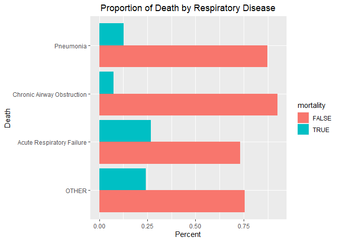

```r
#proportions of deaths by long_title
deaths_by_disease<-data4 %>% dplyr::count (long_title, mortality, sort= TRUE)%>% group_by(long_title)%>% mutate(percent=round(n/sum(n),3))


#Acute Respiratory Failure  TRUE       1299
#OTHER                      TRUE        758
#Pneumonia                  TRUE        342
#Chronic Airway Obstruction TRUE        218



#plot of deaths_by_long_title

ggplot(data=deaths_by_disease)+ geom_col(aes(x=long_title, y= percent,fill=mortality), position = "dodge")+
 labs(title=" Proportion of Death by Respiratory Disease ", x="Death", y="Percent") +
   theme(plot.title = element_text(hjust = 0.5))+
  coord_flip()
```

```r
#comorbidities<- what effect is death rate


#count of comorbidities
data4 %>% dplyr::count (comorbidities, sort= TRUE) # count of comorbidities
```

```
# A tibble: 38 x 2
   comorbidities     n
           <int> <int>
 1             9  2466
 2            14   734
 3            13   697
 4            15   693
 5            12   680
 6            16   664
 7            17   649
 8            11   609
 9             8   580
10            18   573
# ... with 28 more rows
```

```r
# 1             9  2466
# 2            14   734
# 3            13   697
# 4            15   693
# 5            12   680
# 6            16   664
# 7            17   649
# 8            11   609
# 9             8   580
#10            18   573




data4 %>% dplyr::count (comorbidities, mortality, sort= TRUE) # count of
```

```
# A tibble: 76 x 3
   comorbidities mortality     n
           <int> <fct>     <int>
 1             9 FALSE      1979
 2            14 FALSE       610
 3            12 FALSE       584
 4            13 FALSE       581
 5            15 FALSE       581
 6            16 FALSE       540
 7            17 FALSE       522
 8            11 FALSE       514
 9             8 FALSE       496
10             9 TRUE        487
# ... with 66 more rows
```

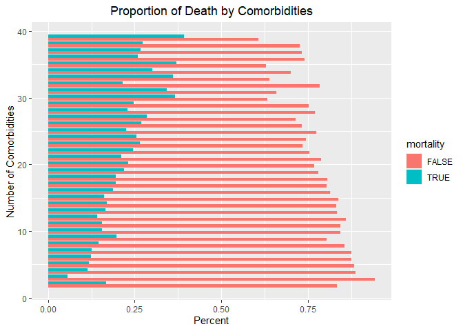

```r
#proportions of deaths by number of comorbidities
deaths_by_comorbidities<-data4 %>% dplyr::count (comorbidities, mortality, sort= TRUE)%>% group_by(comorbidities)%>% mutate(percent=round(n/sum(n),3))

#plot of deaths_by_comorbidities


#
ggplot(data=deaths_by_comorbidities)+ geom_col(aes(x=comorbidities, y= percent,fill=mortality), position = "dodge")+
 labs(title=" Proportion of Death by Comorbidities ", x="Number of Comorbidities", y="Percent") +
   theme(plot.title = element_text(hjust = 0.5))+
  coord_flip()
```

```r
#ethnicity and death


#count of comorbidities
data4 %>% dplyr::count (ethnicity, sort= TRUE) # count of ethnicity
```

```
# A tibble: 6 x 2
  ethnicity         n
  <fct>         <int>
1 WHITE          9969
2 NOT SPECIFIED  1343
3 BLACK          1269
4 HISPANIC        373
5 OTHER           350
6 ASIAN           300
```

```r
# WHITE          9969
# NOT SPECIFIED  1343
# BLACK          1269
# HISPANIC        373
# OTHER           350
# ASIAN           300



data4 %>% dplyr::count (ethnicity, mortality, sort= TRUE)
```

```
# A tibble: 12 x 3
   ethnicity     mortality     n
   <fct>         <fct>     <int>
 1 WHITE         FALSE      8109
 2 WHITE         TRUE       1860
 3 BLACK         FALSE      1085
 4 NOT SPECIFIED FALSE       957
 5 NOT SPECIFIED TRUE        386
 6 HISPANIC      FALSE       314
 7 OTHER         FALSE       284
 8 ASIAN         FALSE       238
 9 BLACK         TRUE        184
10 OTHER         TRUE         66
11 ASIAN         TRUE         62
12 HISPANIC      TRUE         59
```

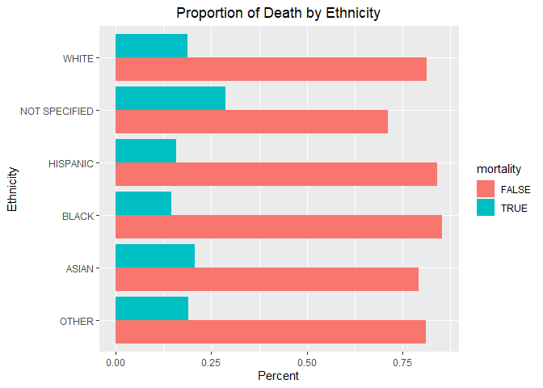

```r
#proportions of deaths by ethnicity
deaths_by_ethnicity<-data4 %>% dplyr::count (ethnicity, mortality, sort= TRUE)%>% group_by(ethnicity)%>% mutate(percent=round(n/sum(n),3))

#plot of deaths_by_comorbidities

ggplot(data=deaths_by_ethnicity)+ geom_col(aes(x=ethnicity, y= percent,fill=mortality), position = "dodge")+
 labs(title=" Proportion of Death by Ethnicity ", x="Ethnicity", y="Percent") +
   theme(plot.title = element_text(hjust = 0.5))+
  coord_flip()
```

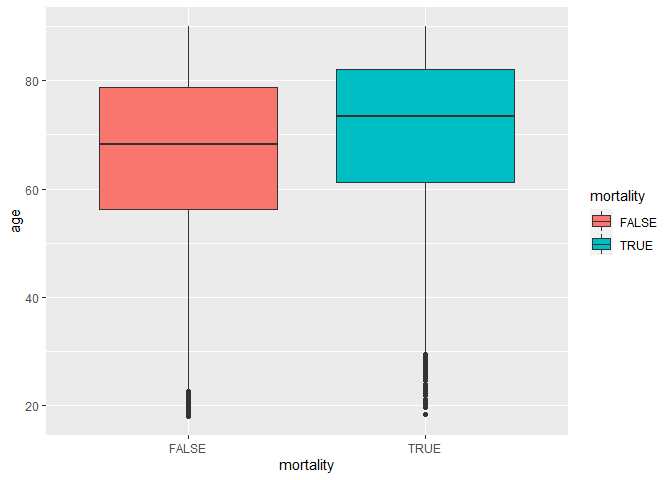

```r
#Not much variation between ethnicities for mortality.


# MORTALITY AND AGE

data4 %>% ggplot(aes(x=mortality, y=age, fill=mortality)) + geom_boxplot()
```

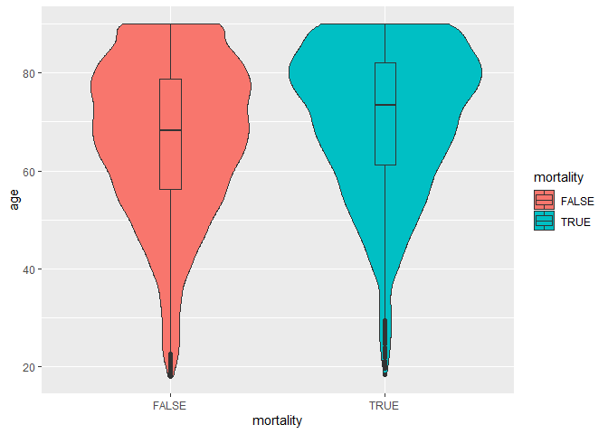

```r
# ANOTHER VIEW OF MORTALITY AND AGE
data4 %>% ggplot(aes(x=mortality, y=age, fill=mortality)) + geom_violin() + geom_boxplot(width=0.1)
```

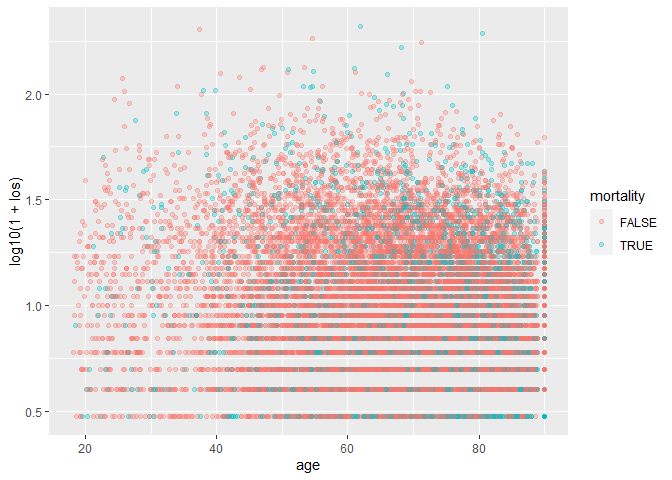

```r
data4 %>% ggplot(aes(x=age, y=log10(1+los), color=mortality)) +
  geom_point(alpha=0.3)
```

-admission_type version Most people in data set were admitted to the emergency room which makes sense with respirtory illnesses. People need may need medicinal support or help from respiratory equipment which makes sense why most would be admitted to the emergency room over elective or urgent care.

The Emergency deparetment high the highest number of total people (over 12170) and the highest number of deaths 2466. Much smaller population of people in elective care 1074 and urgent care 360.Lower number of deaths in Elective care (79) and urgent care (72).

-#proportions of dead/alive in admission type #Emergency and Urgent care had similar proportions of death of about 20%. #Only about a 7% mortalities in elective care. #Lower proportion of death in divorced and single individuals. #Higher proportion of death in married but also more people in data set.

-count of age 875 people 90yr or older , with next highest at 11 people at 63.7yrs old,75.2,75.6

-deaths_by_marital_status Highest is NOT Informed ( NAs people who did not answer) Second highest death rate is in the OTHER category. Divorced had least amount of mortality. Of specific categories ( not: “other” or "not specified) Divorced, married, single or widowed - widowed had highest percentage of mortality. No category stood out very much as they all have similar mortality percentages.

-long_title (respiratory disease name) Most people in data set having diagnosis of Acute Respiratory failure. I am not surprised that more people entering with acute problem over chronic problem. Chronic problems are a slow progression whereas an acute problem can escalate quickly. #Acute respirtory faiure had highest percentage of mortality at 26.8%, the next highest is OTHER at 24.3% , Pneumonia third at 12.6% and chronic airway obstruction the least percentage of mortality at 7.4% The respiratory illness with the highest mortality count is Acute respiratory fairure. I am not surprised by this as acute problems are unexpected and unplanned and can often be riskier for death. When you have a chronic problem, you often are aware and managed by a doctor. Also often taking medications already. With antibiotics, I am also not surprised that less people die of pneumonia that an acute problem.

-age and mortality Plot displays most people in the data set are over 50 years old The median age for mortality was approxiamtely 73 years old. The median age for living was approximately 67. This suggests that the risk of death increases as you approach 70 years old. As length of stay and age increase, more mortality withint the population of the data set.

#modeling will support or reject this conclusion

## MODELING

### MAKING TEST AND TRAIN SET

```
- 5. Split your data into train and test sets.
```

```r
#randomly choosing sample
#when choosing percent : want train bigger than test

set.seed(7)
data4<-select(data4,-discharge_location) # removing discharge location because thats how I made mortality variable


index<-createDataPartition(data4$mortality, p = 0.70, list = FALSE) #randomly choses 70% of indices from indices
train_data<-data4[index ,]

test_data<-data4[-index ,]


trctrl <- trainControl(method = "cv", number = 3, verboseIter = TRUE,
                       summaryFunction = twoClassSummary, classProbs = TRUE) #3 fold cross validation
summary(train_data$mortality)# Alive:  7691   Dead: 1832
```

```
FALSE  TRUE
 7691  1832
```

```r
summary(test_data$mortality) # Alive: 3296   Dead: 785
```

```
FALSE  TRUE
 3296   785
```